# Exploring the BRFSS data

## Setup

### Load packages

```r
library(ggplot2)
library(dplyr)
```

### Load data

Make sure your data and R Markdown files are in the same directory. When loaded your data file will be called `brfss2013`. Delete this note when before you submit your work.

```r
load("brfss2013.RData")
```

## Part 1: Data

The Behavioral Risk Factor Surveillance System (BRFSS) is the nation’s premier system of health-related telephone surveys that collect state data about U.S. residents regarding their health-related risk behaviors, chronic health conditions, and use of preventive services. Established in 1984 with 15 states, BRFSS now collects data in all 50 states as well as the District of Columbia and three U.S. territories. BRFSS completes more than 400,000 adult interviews each year, making it the largest continuously conducted health survey system in the world.

BRFSS data is collected through telephone survey.Telephone number is chosen randomly. A staff will cold call the nmber and ask about health and health practices. As random sampling is used, the data has good generabizability.

However, there are some reservations. A lot of people will refuse telephone surveys for they are busy. Considering there are 30 modules in total in the survey, this is highly likely. In addition, homeless and extremly poor people who do not have a phone are not covered in the survey, who definately have a different health condition.

In addtion, all data here is self-reported, and could be subject to all kinds of bias. It is not clear what impact it will have on the generabizability.

In addition, as the data collected are all observations and reported by the participants, one should be very caucious when drawing conclusions from the data. Causality is not garanteed in oberservational data.

## Part 2: Research questions

Coke and other sweeten drinks has long been believed to cause various health problems, most notablely obesity. Every one of us can come up with some examples of obese people who love their soda. But at the same time, soda is widely consumed by the majority of population, many of who do not experience the syptom. Here, we will look into BRFSS data to see if there is a link.

**Research quesion 1:** Do soda/sweeten drinks lead to obesity?

**Research quesion 2:** Do soda/sweeten drinks lead to heart attack?

**Research quesion 3:** Do soda/sweeten drinks lead to diabetes?

## Part 3: Exploratory data analysis

## Data Cleaning

Drink consumption data is very complex, for example:

```r
table(brfss2013$ssbfrut2)
```

```
##
##     0   101   102   103   104   105   106   107   108   109   110   111
## 54530  6845  2547  1020   417   233    83    45    49     7    43     2
##   112   115   116   120   124   125   130   150   160   201   202   203
##    16     2     2    10     1     2     4     1     1  4814  4148  2757
##   204   205   206   207   208   209   210   212   213   214   215   216
##  1149   850   137   330    20     5    37     7     1     5    11     2
##   220   221   222   223   224   225   227   229   230   233   301   302
##    10     1     1     1     2     3     1     1     3     1  3928  4925
##   303   304   305   306   307   308   309   310   311   312   313   314
##  2483  1756  2553   659   336   324    31  1889    12   250    11    66
##   315   316   317   318   319   320   321   322   323   324   325   326
##  1197    21     5    34     2   918    15    12     3    12   226     4
##   327   328   329   330   331   332   333   335   340   343   345   350
##     4    29     6   985    10     1     4     5    11     1    17     9
##   354   355   360   365   370   375   390   399
##     1     1    40     2     1     2    11     3
```

Here is what the lables are about:

**ssbfrut2**: How Often Did You Drink Sugar-Sweetened Drinks?

Value Value Label

[101 - 199] Times per day

[201 - 299] Times per week

[301 - 399] Times per month

0 Never

NA Refused/Missing

Therefore, we need to clean data before use:

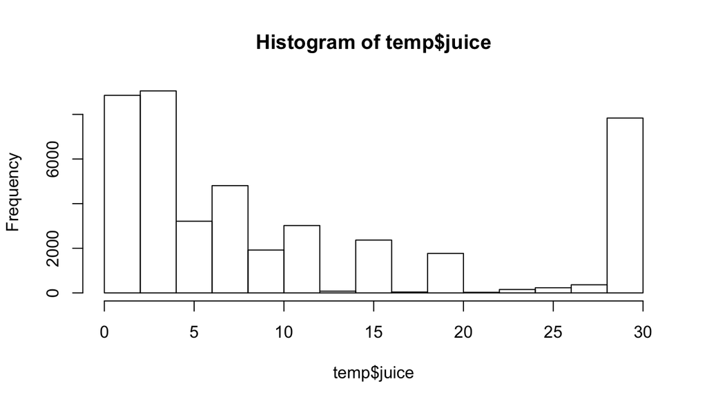

```r
brfss2013$juice <- ifelse(
  brfss2013$ssbfrut2 == 0,
  0,
  ifelse(
    brfss2013$ssbfrut2 <200,
    (brfss2013$ssbfrut2-100)*30,
    ifelse(
      brfss2013$ssbfrut2 <300,
      (brfss2013$ssbfrut2-200)*4,
      brfss2013$ssbfrut2-300
    )
  )
)
temp = brfss2013%>%filter(brfss2013$juice <= 30 & brfss2013$juice >0)
hist(temp$juice)
```

We therefore reclean the data, and it looks much better:

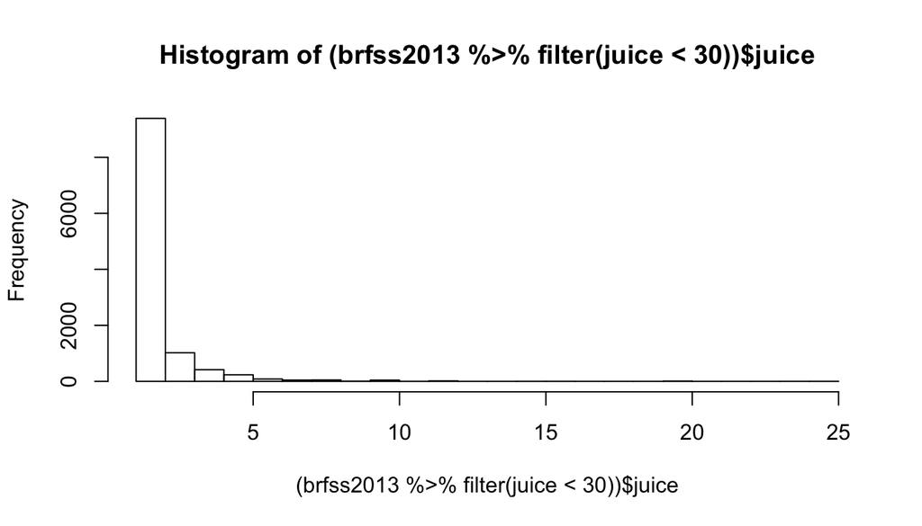

```r
brfss2013$juice <- ifelse(brfss2013$ssbfrut2 > 100 & brfss2013$ssbfrut2 < 200,
                          brfss2013$ssbfrut2-100,
                          NA)
hist((brfss2013%>%filter(juice<30))$juice, breaks = 30)
```

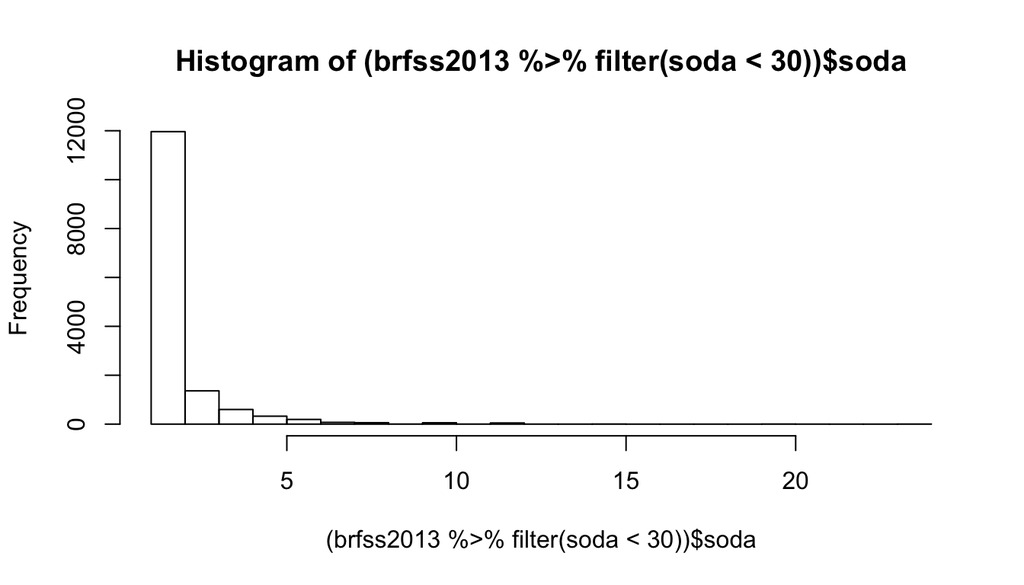

```r
# We do the same thing for sugar, i.e. soda data
brfss2013$soda <- ifelse(brfss2013$ssbsugar > 100 & brfss2013$ssbsugar < 200,
                          brfss2013$ssbsugar-100,
                          NA)
hist((brfss2013%>%filter(soda<30))$soda, breaks = 30)
```

In addition, we will also look at people who drink soda, vs. people who don’t.

```r
brfss2013$drinksoda <- ifelse(brfss2013$ssbsugar > 0,1,ifelse(brfss2013$ssbsugar==0,0,NA))
table(brfss2013$drinksoda)
```

```
##
##     0     1
## 46115 57080
```

```r
brfss2013$drinkjuice <- ifelse(brfss2013$ssbfrut2 > 0,1,ifelse(brfss2013$ssbfrut2==0,0,NA))
table(brfss2013$drinkjuice)
```

```
##
##     0     1
## 54530 48442
```

**Research quesion 1:** before we start, we calclate bmi

```r
brfss2013$weight2 <- as.numeric(brfss2013$weight2)
brfss2013$bmi <- 703*brfss2013$weight2/(brfss2013$htin4**2)
summary(brfss2013$htin4)
```

```
##    Min. 1st Qu.  Median    Mean 3rd Qu.    Max.    NA's
##    2.00   64.00   66.00   66.68   70.00 6804.00    9510
```

We also want to take a look of all parameters in question:

```r
summary(brfss2013%>%select(juice, soda, drinksoda, drinkjuice, bmi))
```

```
##      juice             soda          drinksoda        drinkjuice
##  Min.   : 1.0     Min.   : 1.0     Min.   :0.0      Min.   :0.0
##  1st Qu.: 1.0     1st Qu.: 1.0     1st Qu.:0.0      1st Qu.:0.0
##  Median : 1.0     Median : 1.0     Median :1.0      Median :0.0
##  Mean   : 1.8     Mean   : 1.9     Mean   :0.6      Mean   :0.5
##  3rd Qu.: 2.0     3rd Qu.: 2.0     3rd Qu.:1.0      3rd Qu.:1.0
##  Max.   :60.0     Max.   :40.0     Max.   :1.0      Max.   :1.0
##  NA's   :480445   NA's   :477078   NA's   :388580   NA's   :388803
##       bmi
##  Min.   :    0.001
##  1st Qu.:    7.604
##  Median :   11.432
##  Mean   :   12.637
##  3rd Qu.:   15.659
##  Max.   :17926.500
##  NA's   :9510
```

As indicated below, if you drink juice on daily basis, driking juice has little relationship with your weight.

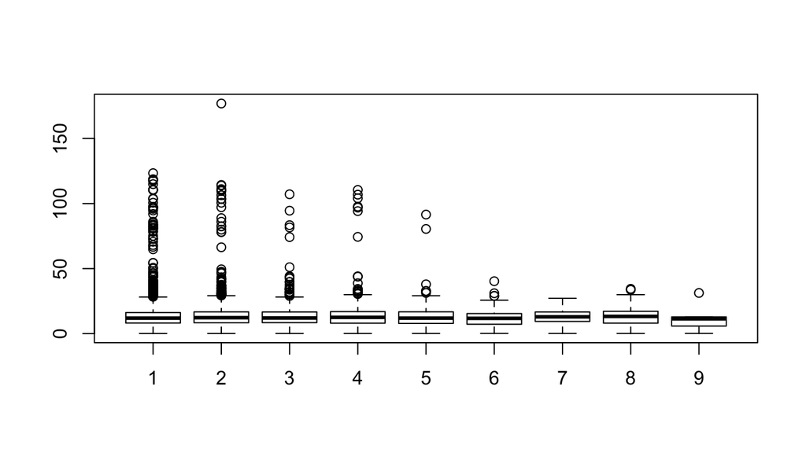

```r
temp <- brfss2013%>%filter(juice<10)
boxplot(temp$bmi~temp$juice)
```

The same thing ca be said to soda:

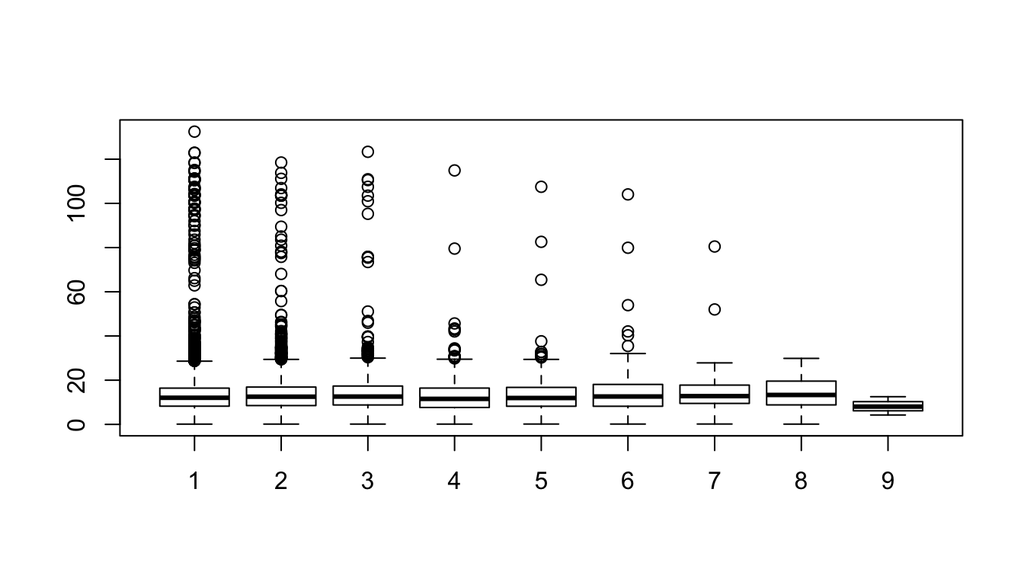

```r
temp <- brfss2013%>%filter(soda<10)
boxplot(temp$bmi~temp$soda)
```

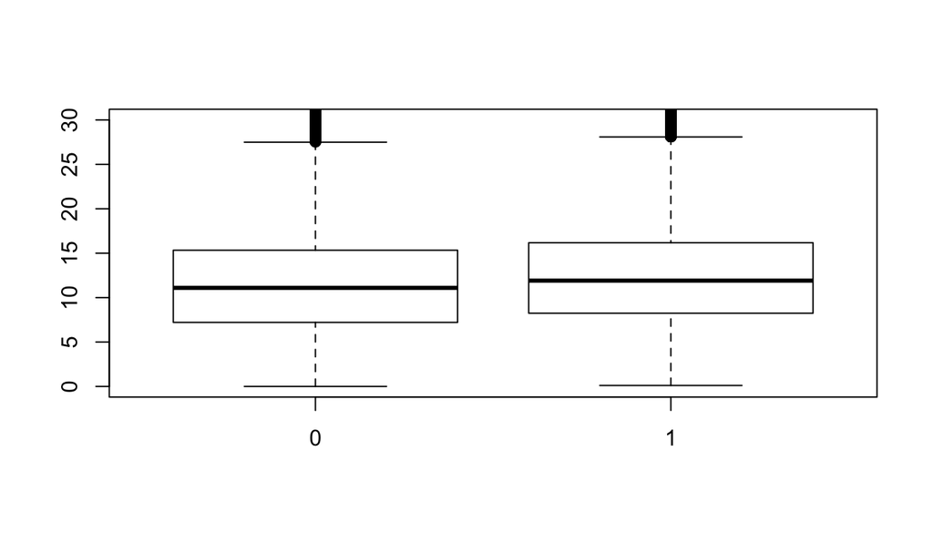

```r
boxplot(brfss2013$bmi~brfss2013$drinksoda, ylim=c(0,30))
```

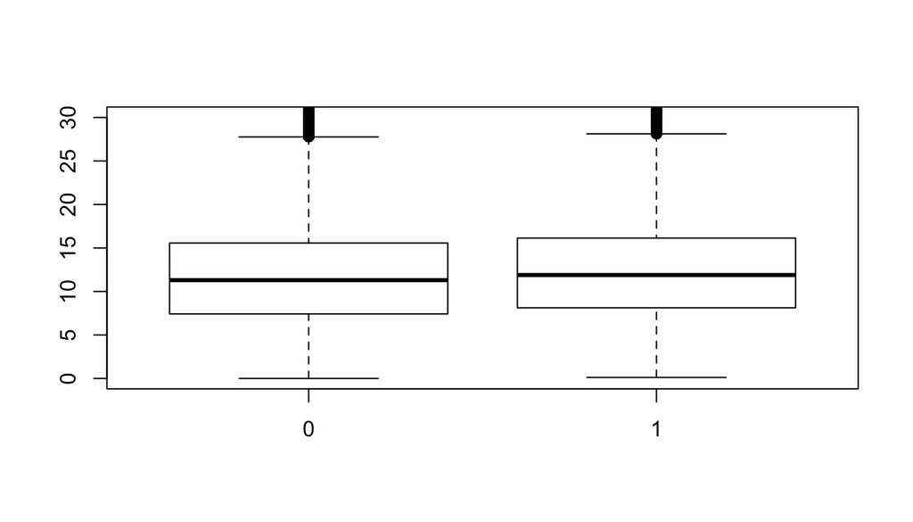

```r
boxplot(brfss2013$bmi~brfss2013$drinkjuice, ylim=c(0,30))
```

**Research quesion 2:** We want to take a look of all parameters in question:

```r
summary(brfss2013%>%select(juice, soda, drinksoda, drinkjuice, cvdinfr4))
```

```
##      juice             soda          drinksoda        drinkjuice
##  Min.   : 1.0     Min.   : 1.0     Min.   :0.0      Min.   :0.0
##  1st Qu.: 1.0     1st Qu.: 1.0     1st Qu.:0.0      1st Qu.:0.0
##  Median : 1.0     Median : 1.0     Median :1.0      Median :0.0
##  Mean   : 1.8     Mean   : 1.9     Mean   :0.6      Mean   :0.5
##  3rd Qu.: 2.0     3rd Qu.: 2.0     3rd Qu.:1.0      3rd Qu.:1.0
##  Max.   :60.0     Max.   :40.0     Max.   :1.0      Max.   :1.0
##  NA's   :480445   NA's   :477078   NA's   :388580   NA's   :388803
##  cvdinfr4
##  Yes : 29284
##  No  :459904
##  NA's:  2587
##
##
##
##
```

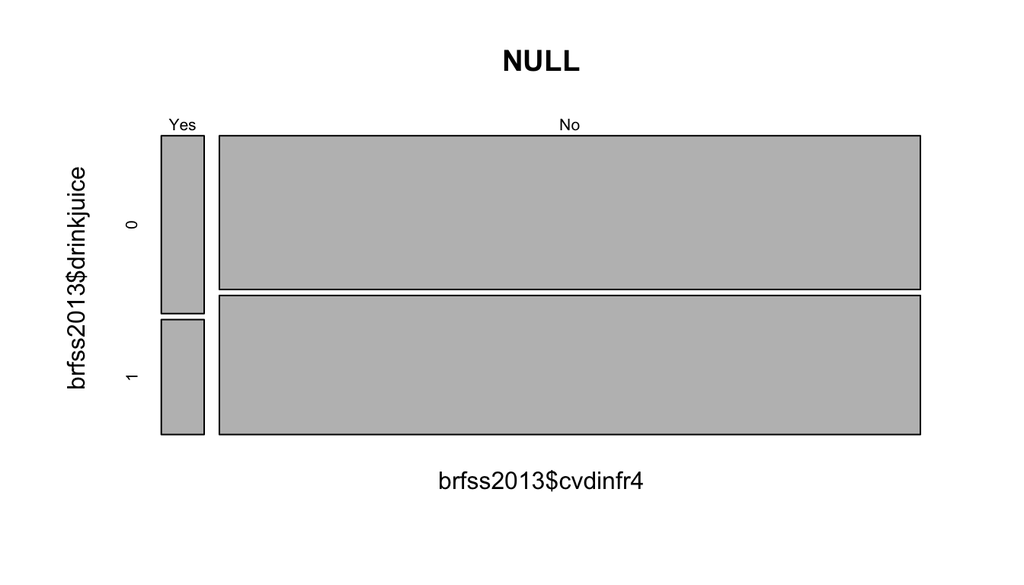

```r
mosaicplot(brfss2013$cvdinfr4~brfss2013$drinkjuice, ylim=c(0,30))
```

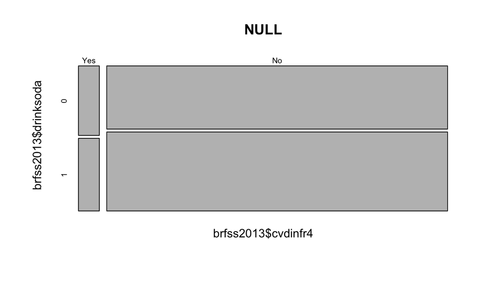

```r
mosaicplot(brfss2013$cvdinfr4~brfss2013$drinksoda, ylim=c(0,30))
```

**Research quesion 3:**

```r
summary(brfss2013%>%select(juice, soda, drinksoda, drinkjuice, diabete3))
```

```
##      juice             soda          drinksoda        drinkjuice
##  Min.   : 1.0     Min.   : 1.0     Min.   :0.0      Min.   :0.0
##  1st Qu.: 1.0     1st Qu.: 1.0     1st Qu.:0.0      1st Qu.:0.0
##  Median : 1.0     Median : 1.0     Median :1.0      Median :0.0
##  Mean   : 1.8     Mean   : 1.9     Mean   :0.6      Mean   :0.5
##  3rd Qu.: 2.0     3rd Qu.: 2.0     3rd Qu.:1.0      3rd Qu.:1.0
##  Max.   :60.0     Max.   :40.0     Max.   :1.0      Max.   :1.0
##  NA's   :480445   NA's   :477078   NA's   :388580   NA's   :388803
##                                        diabete3
##  Yes                                       : 62363
##  Yes, but female told only during pregnancy:  4602
##  No                                        :415374
##  No, pre-diabetes or borderline diabetes   :  8604
##  NA's                                      :   832
##
##
```

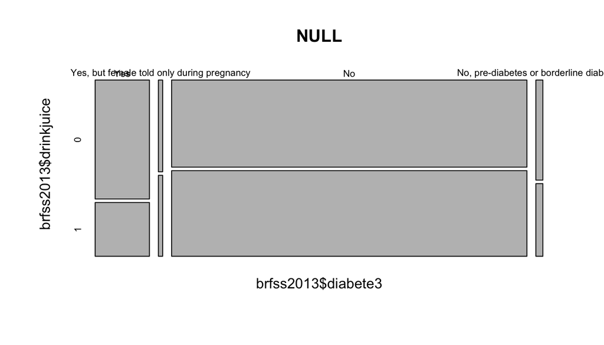

```r
mosaicplot(brfss2013$diabete3~brfss2013$drinkjuice, ylim=c(0,30))
```

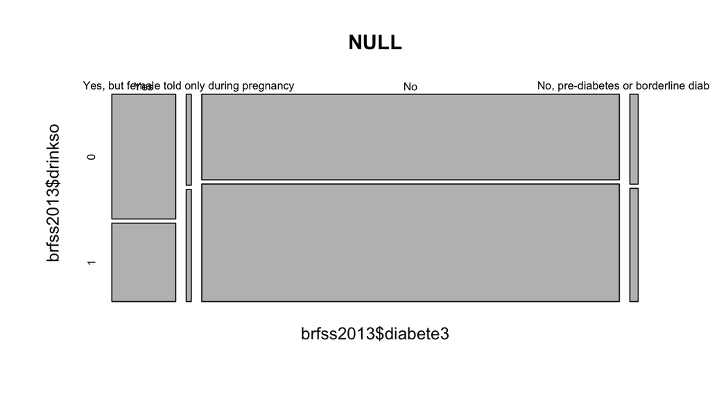

```r
mosaicplot(brfss2013$diabete3~brfss2013$drinkso, ylim=c(0,30))
```